# E.Coli and S.Aureus Absorbances

ContextBase, contextbase.github.io

John Akwei, ECMp ERMp Data Scientist

January 21, 2016

# Synopsis

The objective of this document is to do statistical analysis on absorbance datasets. Via Data Science analysis, (using the R programming language), the document author intends to build an understanding, numerically and statistically, of the difference between the samples, with p-values, t-tests, etc.

The free, open source application RStudio, (version 0.98.1103), was used for the analysis. The version of the R programming language used was, R version 3.2.0 (2015-04-16). The PC operating system is Windows 8.1.

## Table of Contents

1. Graphs of Data
2. Linear Regression, Correlation, and T-Tests
3. Conclusions

# 1) Graphs of Data

#### The data is cleaned. Each row is a separate record. The first row contains the variable names. Then the cleaned data is read into R:

#### Processing Requirements

```r
setwd("C:/Users/johnakwei/Dropbox/Programming/Morphotypes")
if (!require("ggplot2")) {install.packages("ggplot2"); require("ggplot2")}
```

#### Data Input

```r
absorbance1 <- read.csv("Absorbances1.csv", header=T)
absorbance2 <- read.csv("Absorbances2.csv", header=T)
```

#### Exploratory Data Analysis

```r
names(absorbance1)
```

```
## [1] "Powder_mg_vs_Absorbance_E_coli" "Sample_1"
## [3] "Sample_2"                       "Sample_3"
## [5] "Sample_4"                       "Sample_5"
## [7] "Sample_6"                       "Sample_7"
```

```r
names(absorbance2)
```

```
## [1] "Powder_Mg_vs_S_aureus" "Sample_1"              "Sample_2"
## [4] "Sample_3"              "Sample_4"              "Sample_5"
## [7] "Sample_6"              "Sample_7"
```

```r
absorbance1$Powder_mg_vs_Absorbance_E_coli <- as.numeric(absorbance1$Powder_mg_vs_Absorbance_E_coli)
absorbance2$Powder_Mg_vs_S_aureus <- as.numeric(absorbance2$Powder_Mg_vs_S_aureus)
```

## Graphs

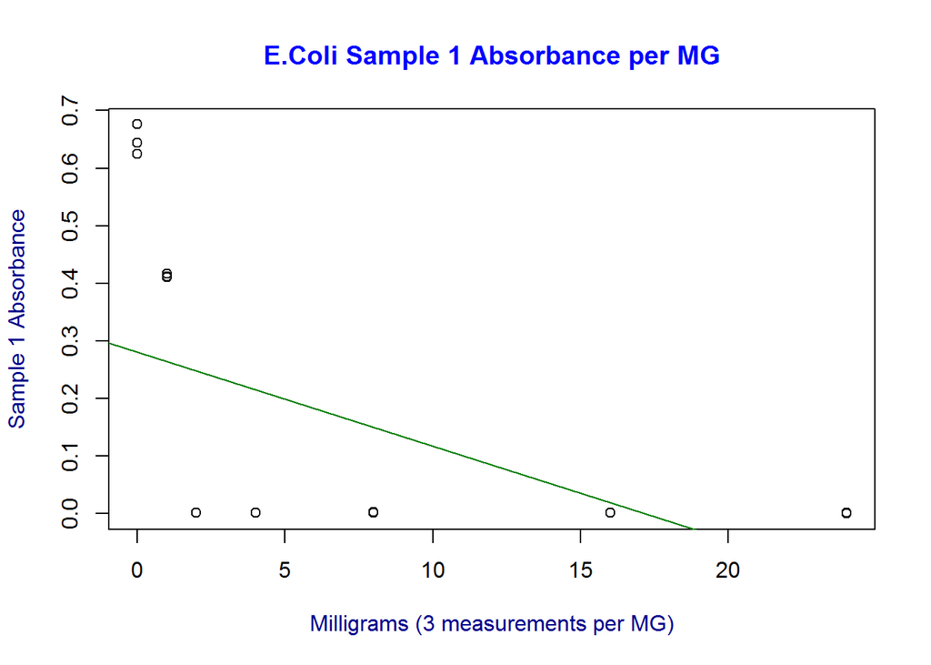

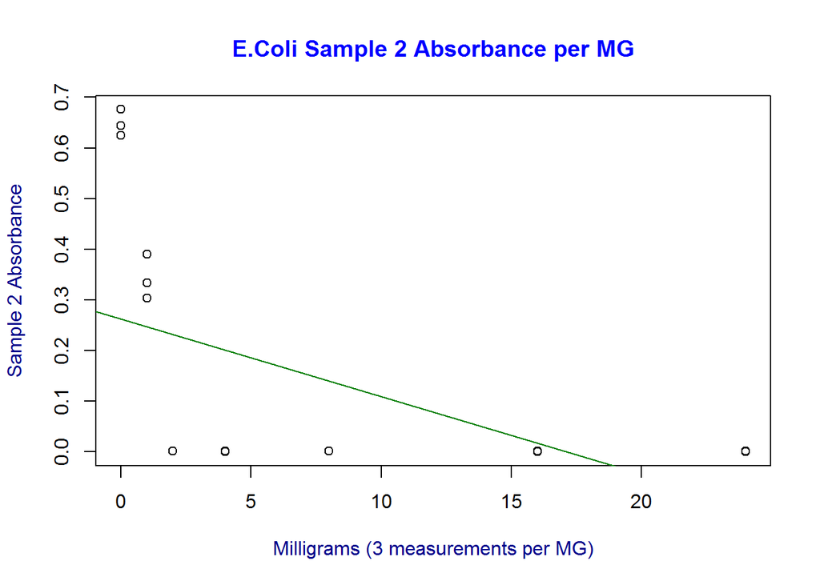

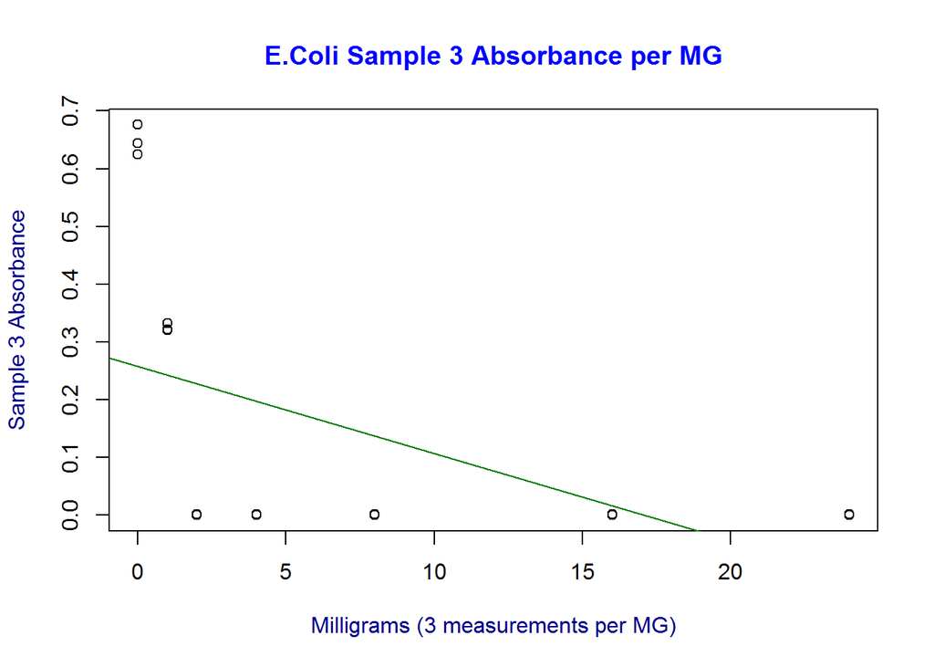

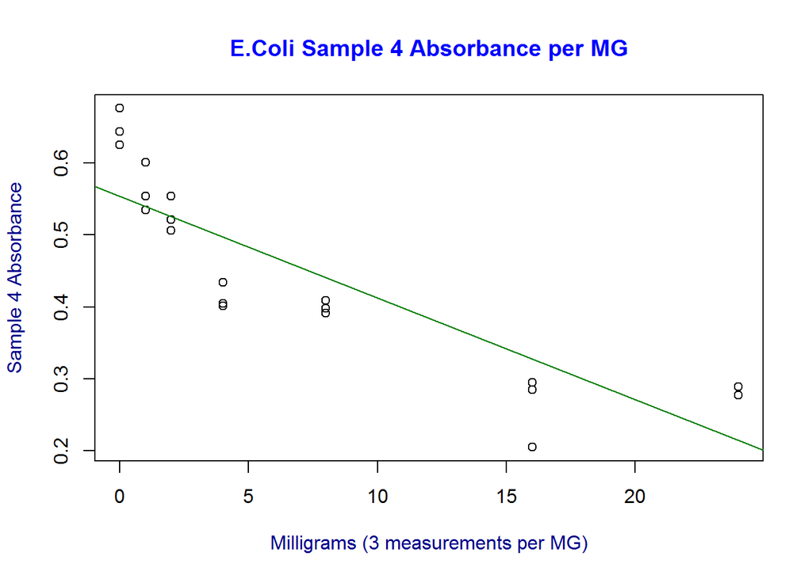

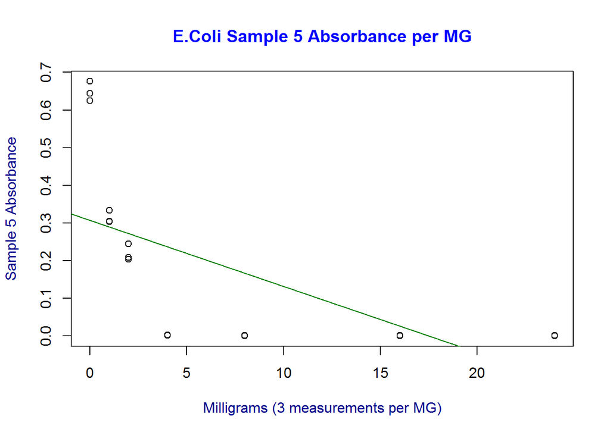

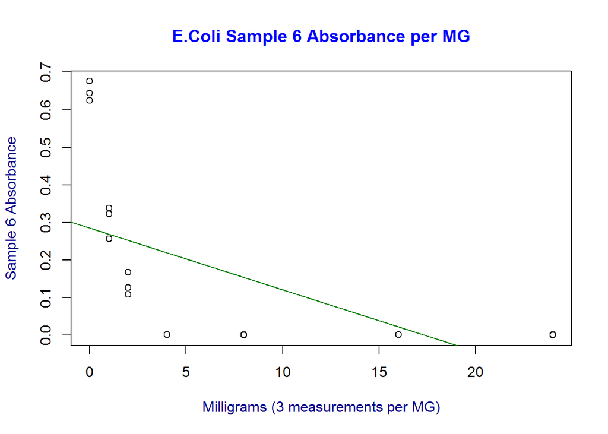

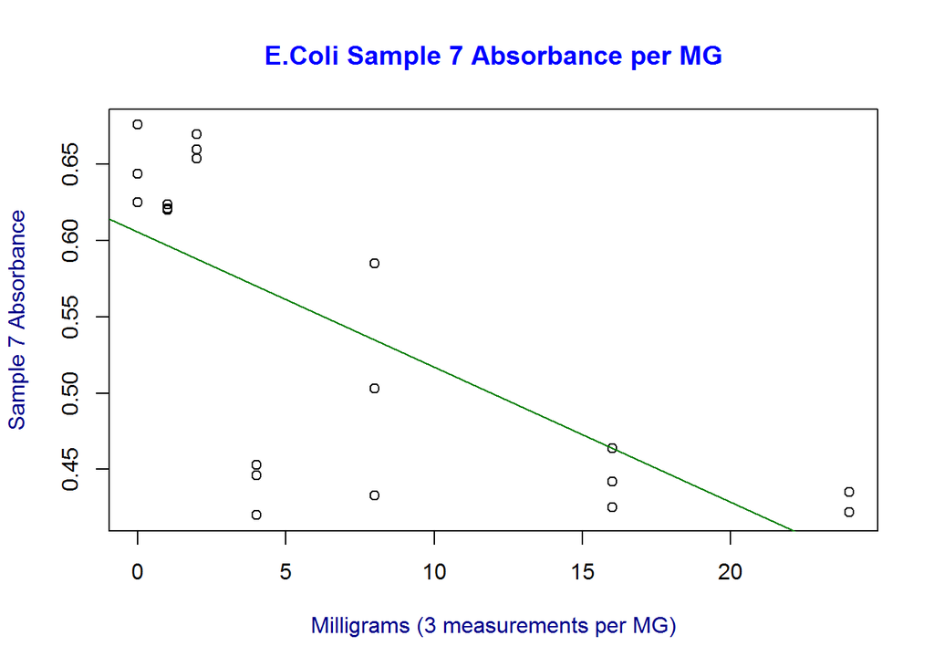

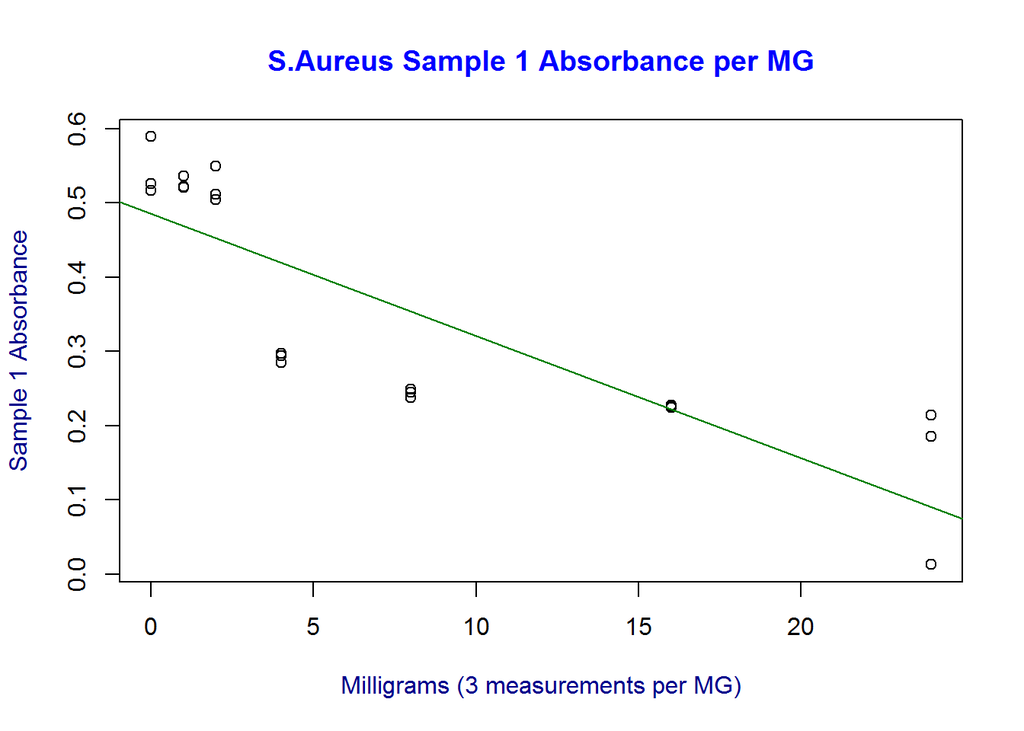

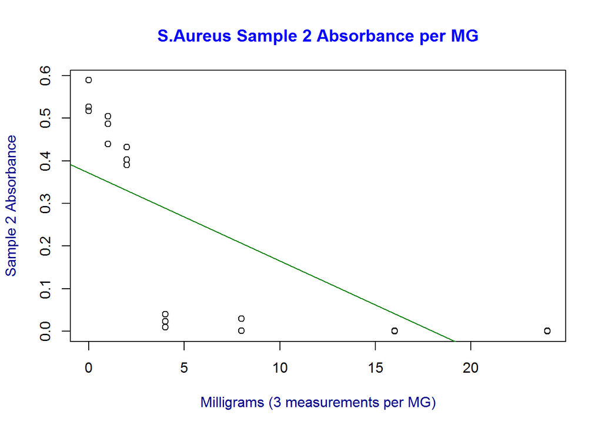

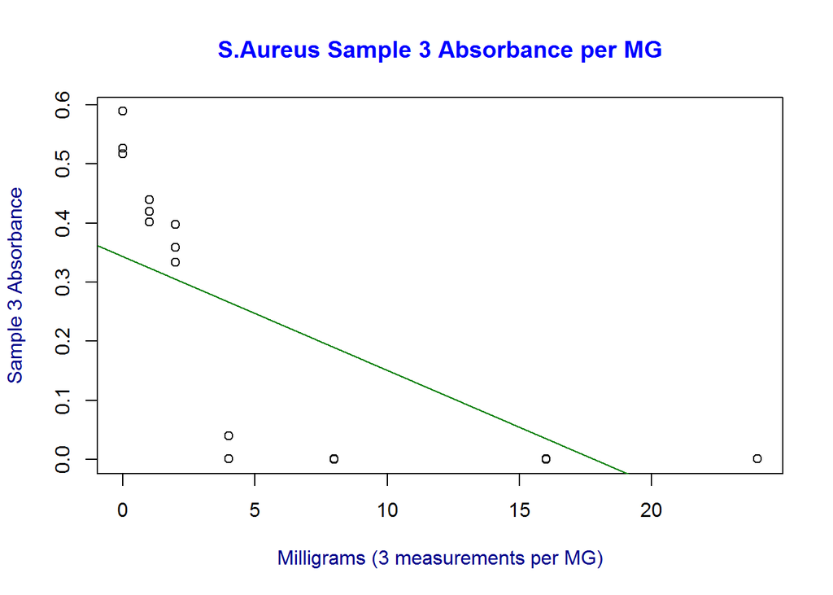

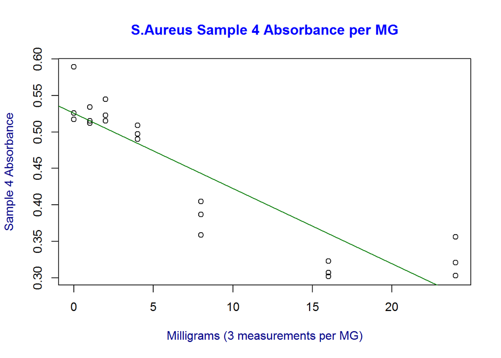

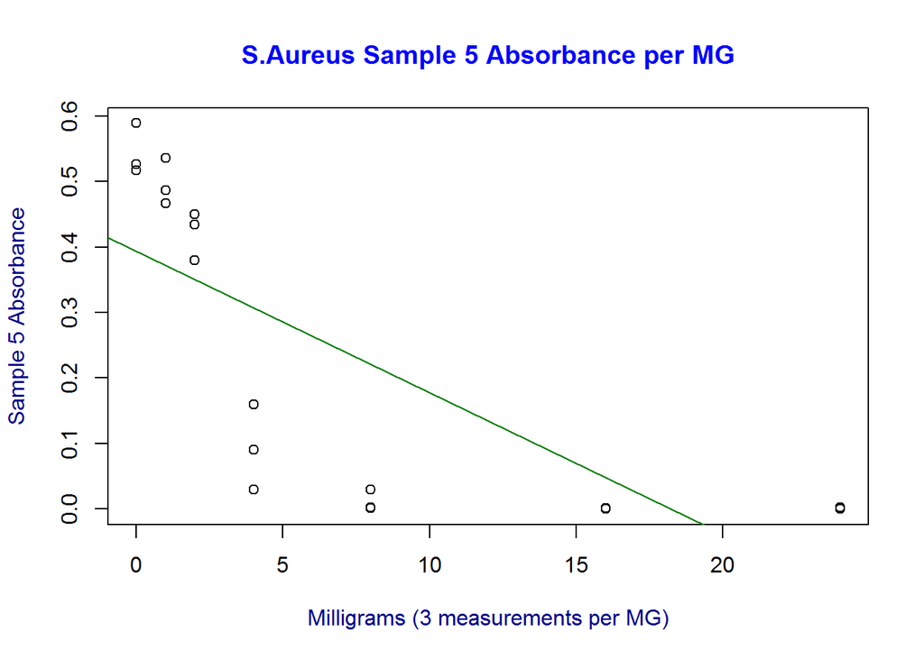

[16 more figures not shown]

#### E.Coli Sample 1 - Sums of 3 Measurements per MG

```
##     0     1     2     4     8    16    24
## 1.945 1.240 0.004 0.004 0.006 0.004 0.001
```

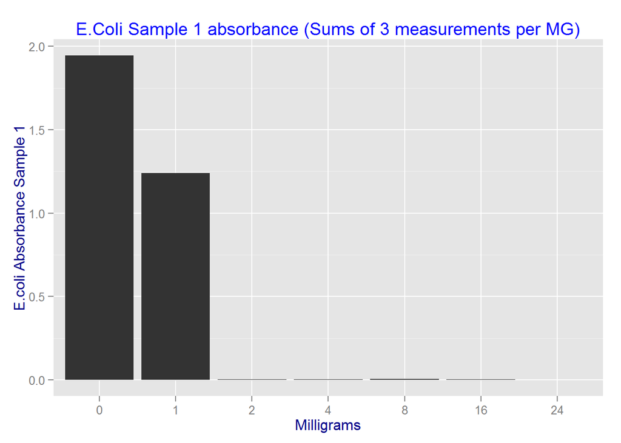

```
##     0     1     2     4     8    16    24
## 1.945 1.027 0.004 0.002 0.004 0.002 0.002
```

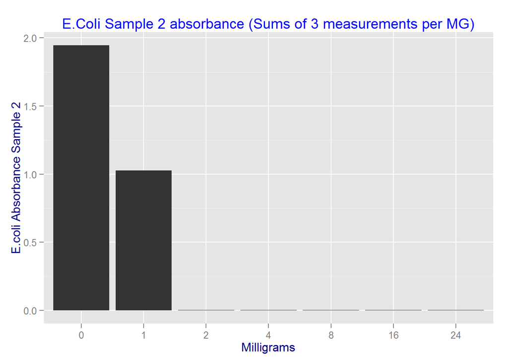

```
##      0      1      2      4      8     16     24
## 1.9450 0.9730 0.0010 0.0020 0.0020 0.0020 0.0021
```

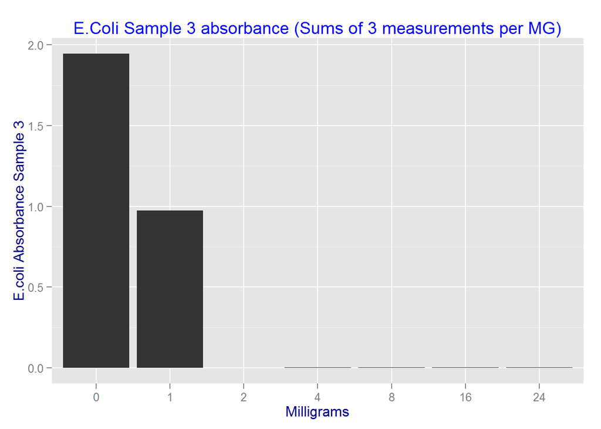

```
##     0     1     2     4     8    16    24
## 1.945 1.690 1.581 1.240 1.198 0.785 0.855
```

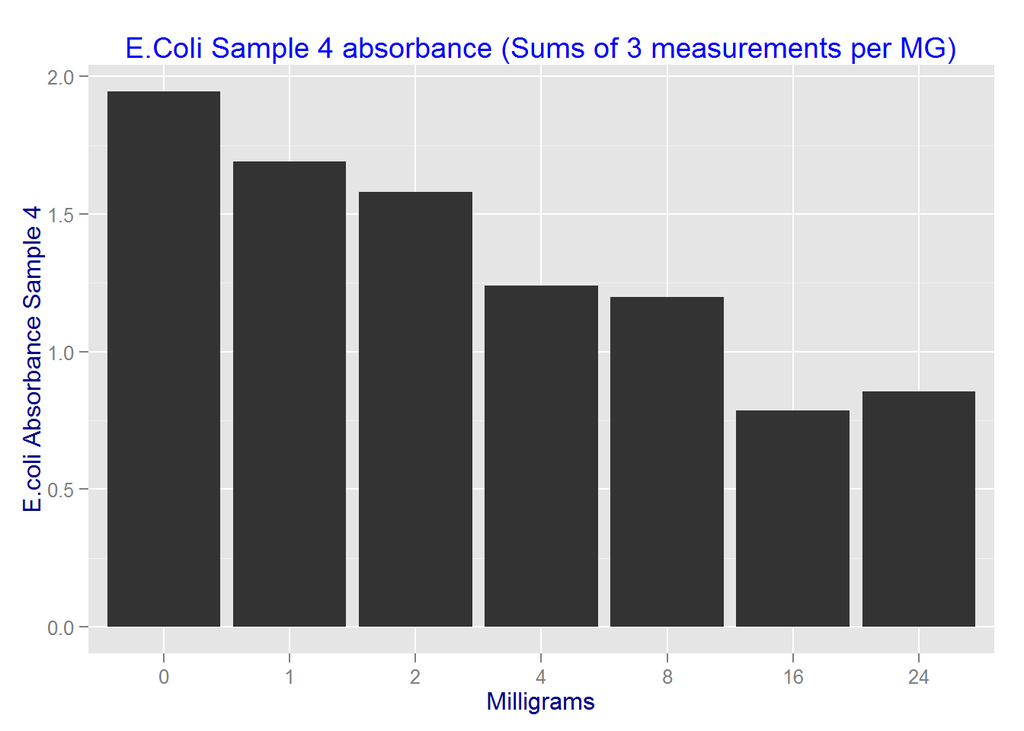

```
##     0     1     2     4     8    16    24
## 1.945 0.941 0.658 0.007 0.002 0.001 0.002
```

[figure not shown]

```
##     0     1     2     4     8    16    24
## 1.945 0.917 0.402 0.003 0.002 0.004 0.002
```

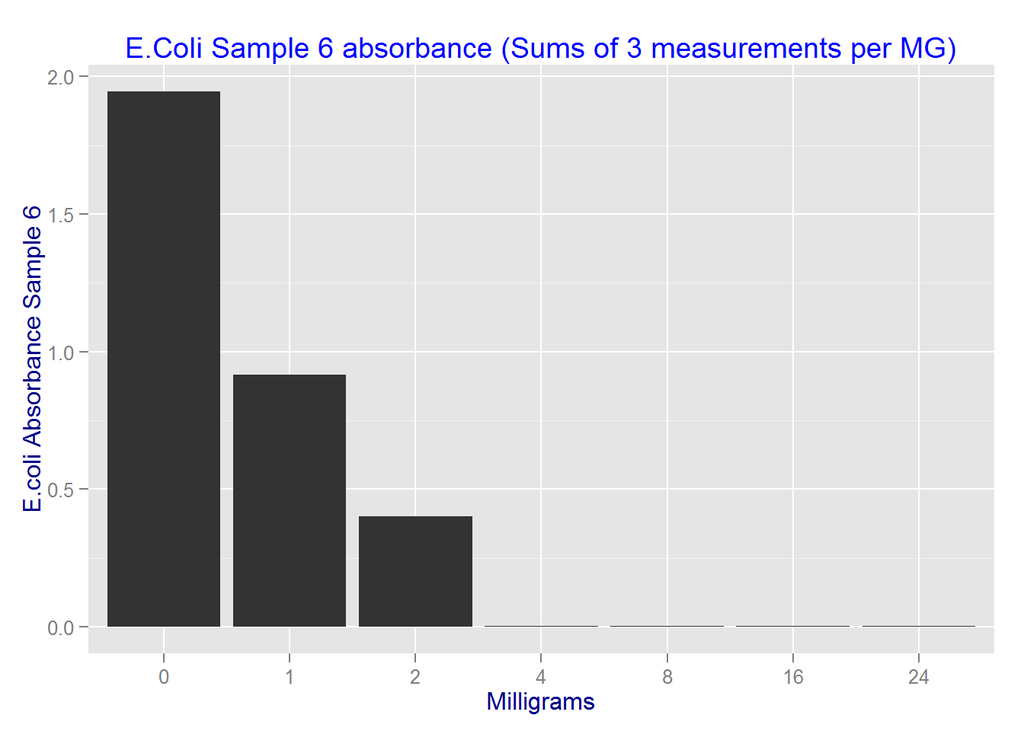

```
##     0     1     2     4     8    16    24
## 1.945 1.865 1.984 1.319 1.521 1.331 1.292
```

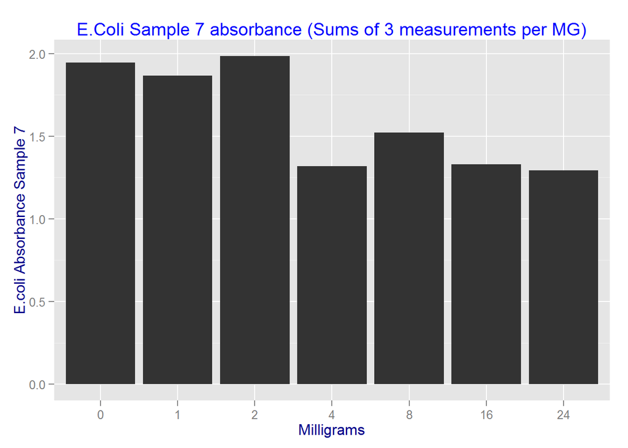

#### S.Aureus Sample 1 - Sums of 3 Measurements per MG

```
##     0     1     2     4     8    16    24
## 1.632 1.579 1.565 0.876 0.732 0.676 0.412
```

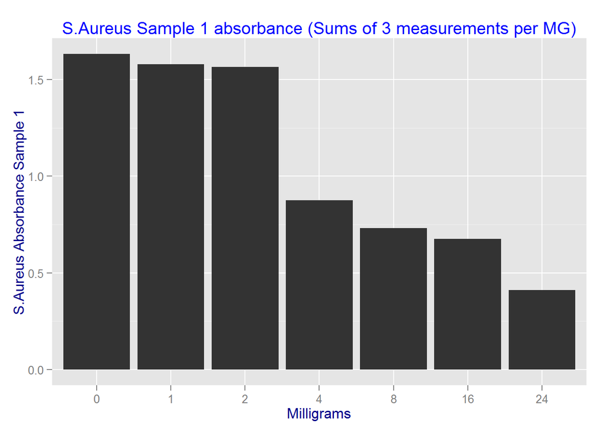

```
##     0     1     2     4     8    16    24
## 1.632 1.431 1.225 0.073 0.032 0.001 0.002
```

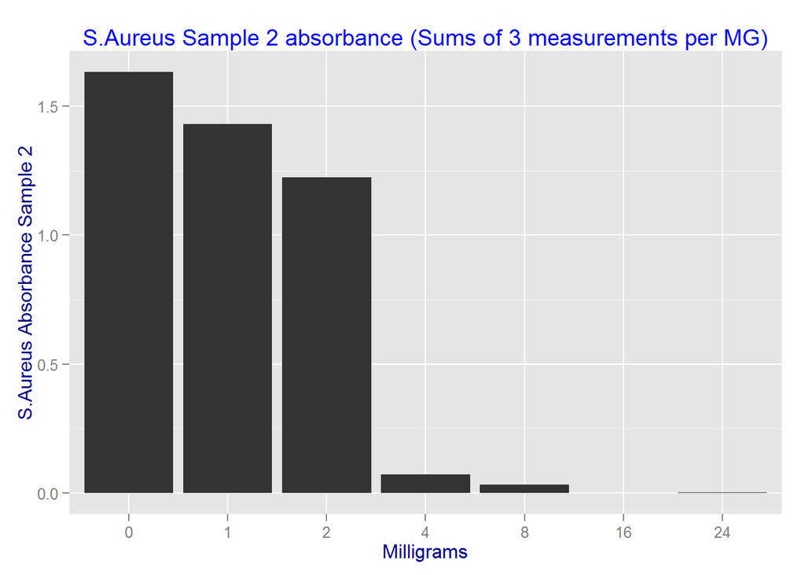

```
##     0     1     2     4     8    16    24
## 1.632 1.261 1.091 0.042 0.002 0.002 0.003
```

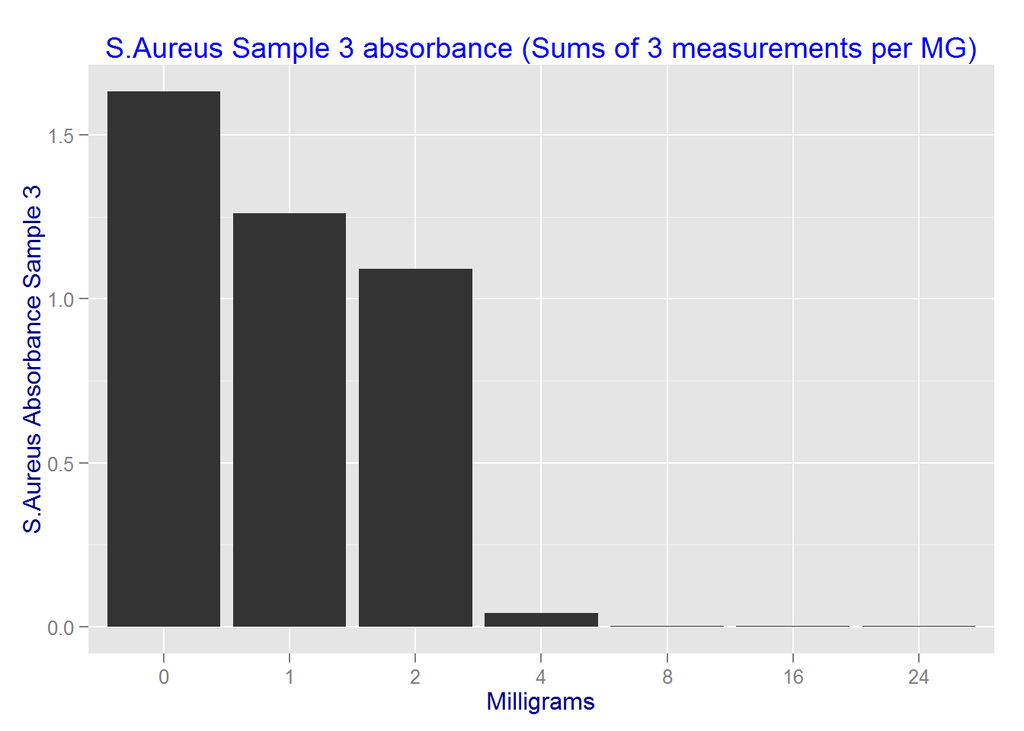

```
##     0     1     2     4     8    16    24
## 1.632 1.561 1.583 1.496 1.151 0.932 0.980
```

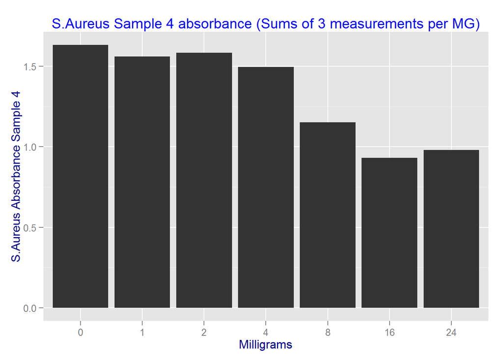

```
##     0     1     2     4     8    16    24
## 1.632 1.490 1.264 0.280 0.033 0.001 0.003
```

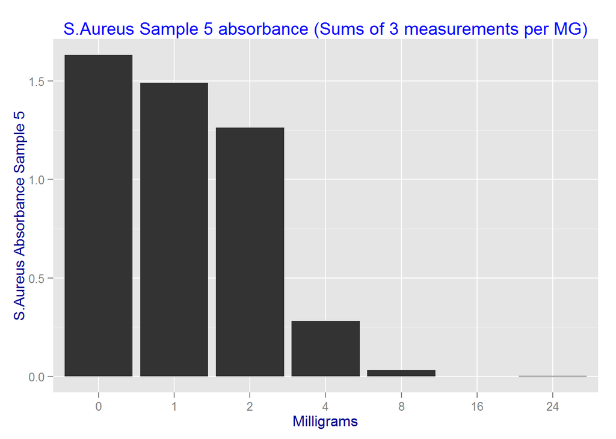

```
##     0     1     2     4     8    16    24
## 1.632 1.510 1.247 0.095 0.005 0.005 0.002
```

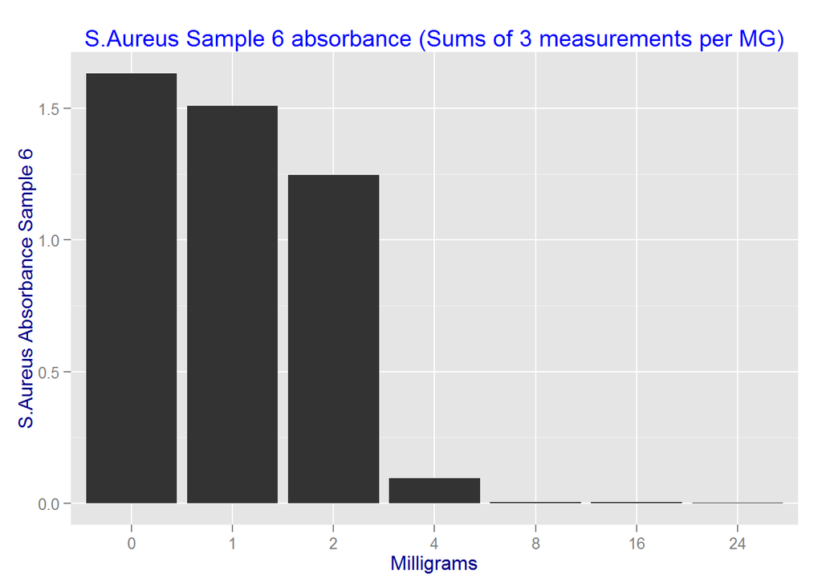

```
##     0     1     2     4     8    16    24
## 1.632 1.637 1.579 1.572 1.362 1.174 1.089
```

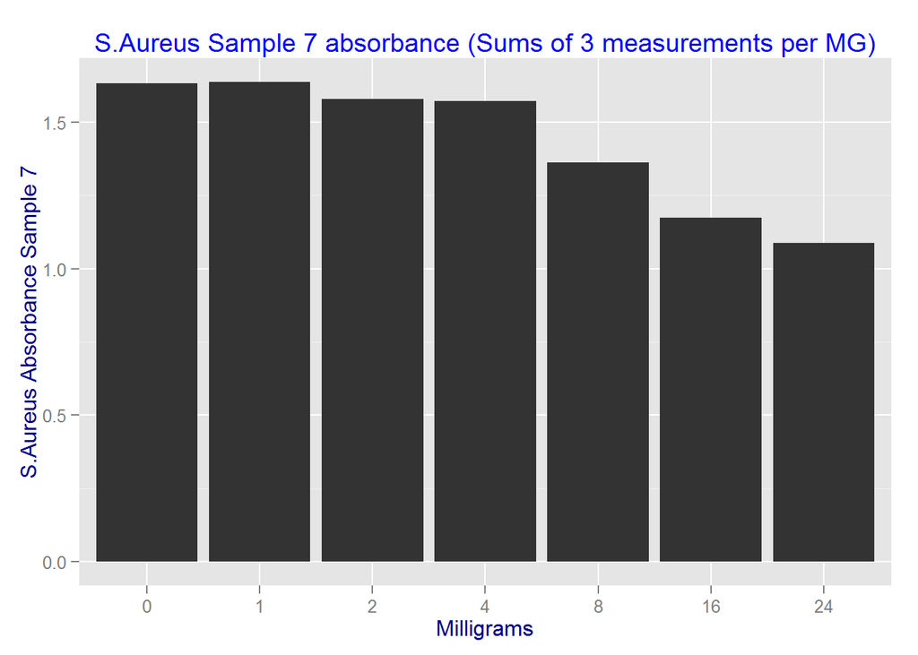

# 2) Linear Regression, Correlation, and T-Tests

#### Linear Regression of E.Coli Sample 1 Data

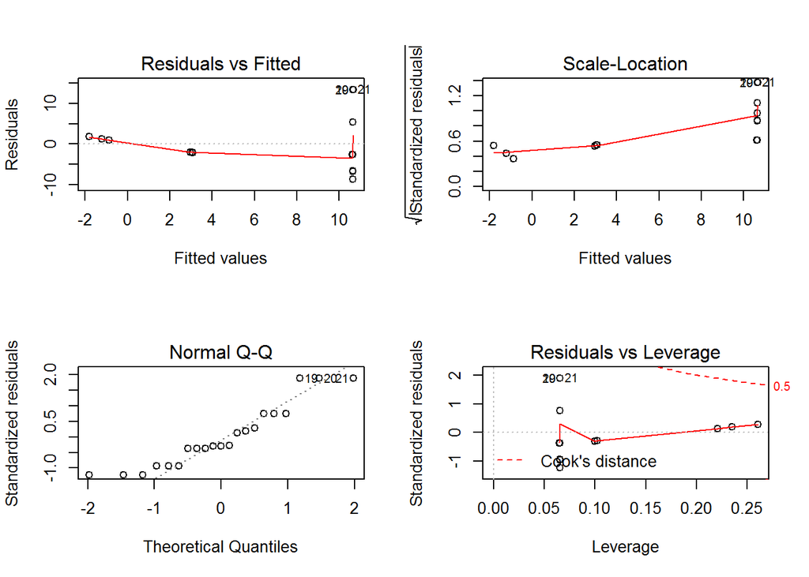

```r
fit <- lm(absorbance1$Powder_mg_vs_Absorbance_E_coli~
                           absorbance1$Sample_1, na.rm=T)
layout(matrix(c(1,2,3,4),2,2))
plot(fit)
```

#### Linear Regression of E.Coli Sample 2 Data

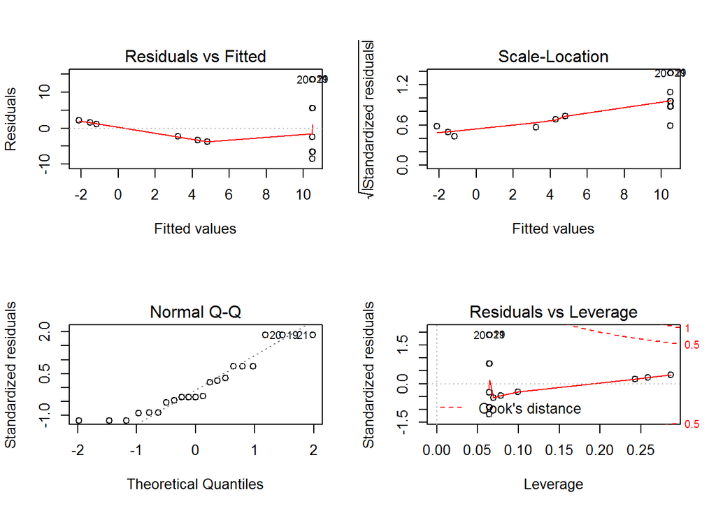

#### Linear Regression of E.Coli Sample 3 Data

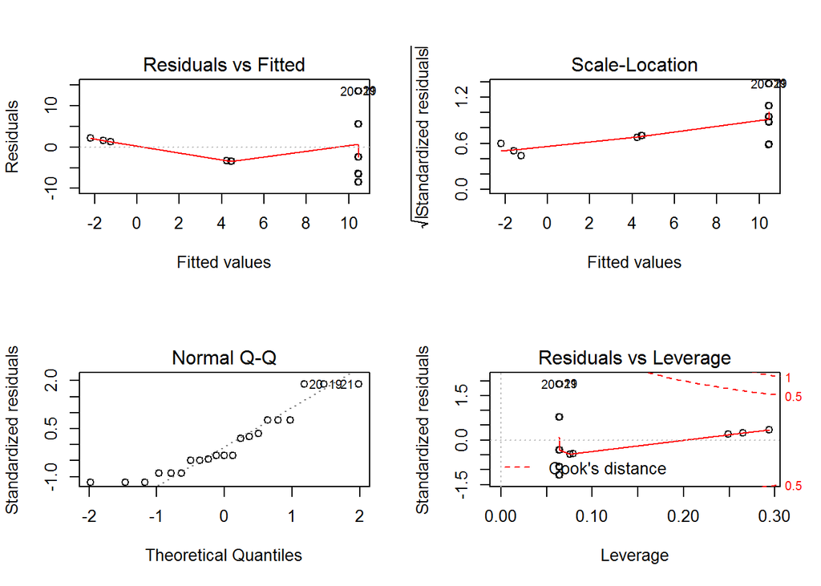

#### Linear Regression of E.Coli Sample 4 Data

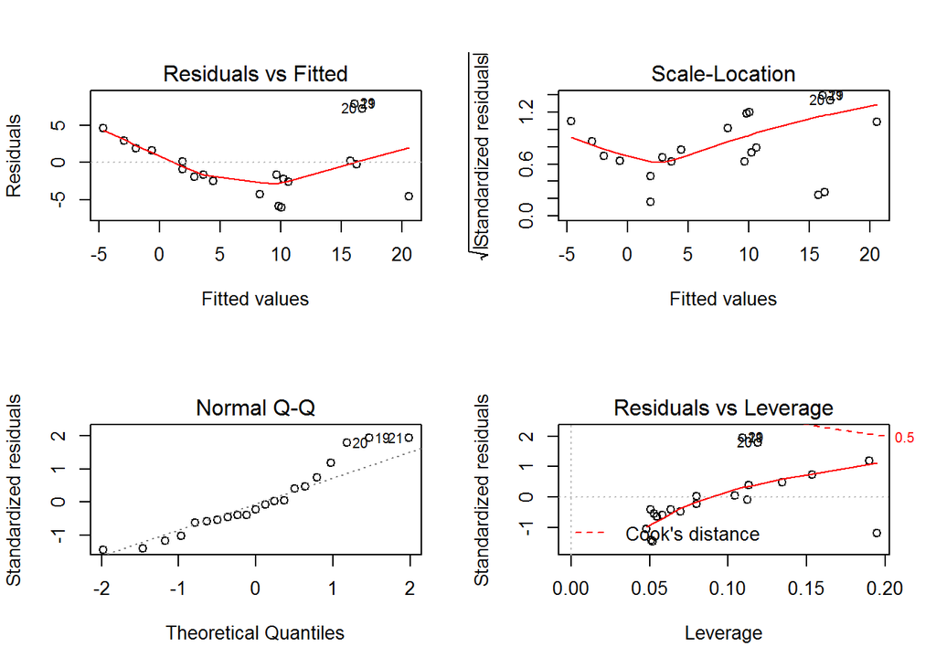

#### Linear Regression of E.Coli Sample 5 Data

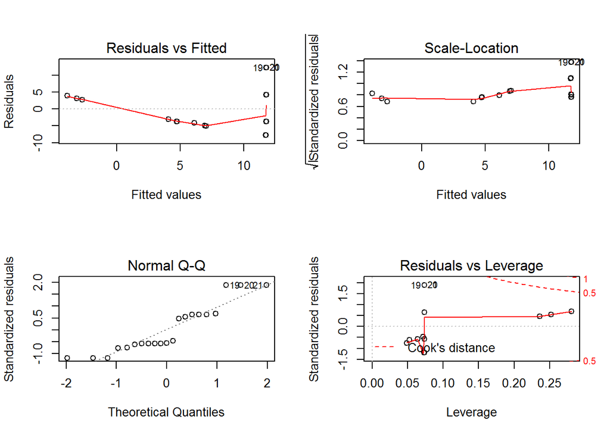

#### Linear Regression of E.Coli Sample 6 Data

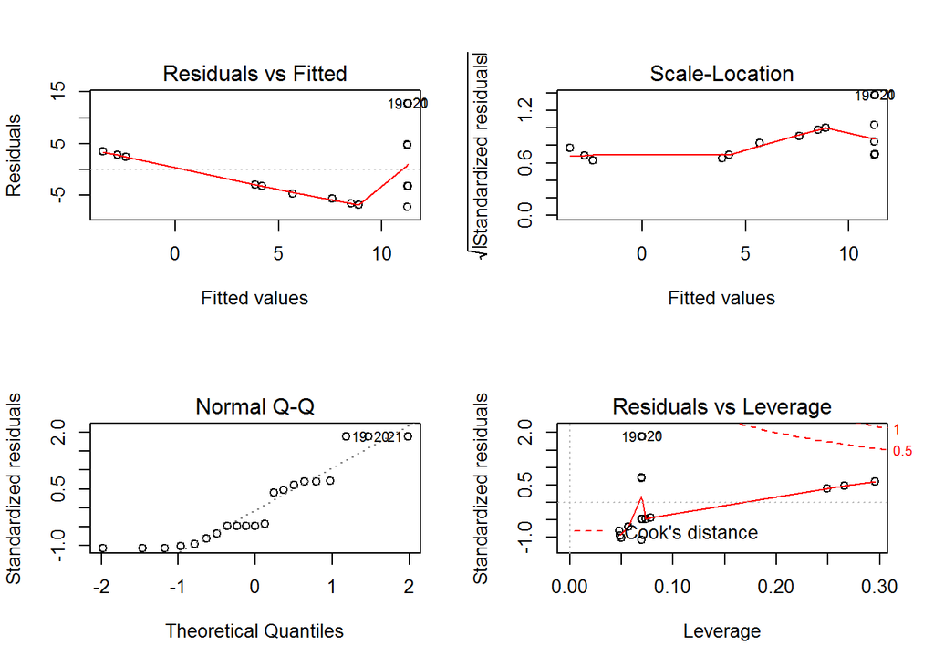